# DATA 606 Notes - Week 1

# Jan 31, 2018

## The DATA606 R Package

The package can be installed from Github using the devtools package.

`devtools::install_github('jbryer/DATA606')`

### Important Functions

| Function | Description |
| --- | --- |
| `devtools::install_github('jbryer/DATA606')` | Install package from Github using devtools |
| `library('DATA606')` | Load the package |
| `vignette(package='DATA606')` | Lists vignettes in the DATA606 package |
| `vignette('os3')` | Loads a PDF of the OpenIntro Statistics book |
| `data(package='DATA606')` | Lists data available in the package |
| `getLabs()` | Returns a list of the available labs |
| `viewLab('Lab0')` | Opens Lab0 in the default web browser |
| `startLab('Lab0')` | Starts Lab0 (copies to getwd()), opens the Rmd file |
| `shiny_demo()` | Lists available Shiny apps |
| `getwd()` | get the working directory |
| `setwd()` | get the working directory |

R Markdown files are provided for all the labs. You can start a lab using the `DATA606::startLab` function.

However, creating new R Markdown files in RStudio can be done by clicking File > New File > R Markdown.

In RStudio, you can also set the working directory on the Files tab by clicking More, then Set as Working Directory.

## Intro to Data

```r
#devtools::install_github("seankross/lego")
library(lego)
data(legosets)
```

## Contingency Tables

```r
table(legosets$Availability, useNA='ifany')
```

```
##
##        LEGO exclusive    LEGOLAND exclusive         Not specified
##                   695                     2                  1795
##           Promotional Promotional (Airline)                Retail
##                   141                    12                  3120
##      Retail - limited               Unknown
##                   403                     4
```

Creates a table of totals for the availabiliy variable in the legosets dataframe - Part of the Base R package

```r
table(legosets$Availability, legosets$Packaging, useNA='ifany')
```

```
##
##                         Blister pack  Box Box with backing card Bucket
##   LEGO exclusive                  45  147                     0      1
##   LEGOLAND exclusive               0    2                     0      0
##   Not specified                    0   20                     0      0
##   Promotional                      0   44                     0      0
##   Promotional (Airline)            0   11                     0      0
##   Retail                          53 2575                    16     30
##   Retail - limited                 2  302                     1      5
##   Unknown                          0    1                     0      0
##
##                         Canister Foil pack Loose Parts Not specified Other
##   LEGO exclusive               0         0          71             7     5
##   LEGOLAND exclusive           0         0           0             0     0
##   Not specified                0         5           0          1739     0
##   Promotional                  0         0           1             0     3
##   Promotional (Airline)        0         0           0             1     0
##   Retail                      78       285           0             0    28
##   Retail - limited             0         1           0             0     0
##   Unknown                      0         0           0             0     0
##
##                         Plastic box Polybag Shrink-wrapped  Tag  Tub
##   LEGO exclusive                  1     412              0    6    0
##   LEGOLAND exclusive              0       0              0    0    0
##   Not specified                   6      24              0    0    1
##   Promotional                     2      90              0    0    1
##   Promotional (Airline)           0       0              0    0    0
##   Retail                          0       4             18    0   33
##   Retail - limited                1      86              0    0    5
##   Unknown                         0       3              0    0    0
```

Creates a table of totals for the availabiliy variable in the legosets dataframe for each packaging option

`useNA='ifany'` - Will ensure any missing values are counted

## Proportional Tables

```r
prop.table(table(legosets$Availability))
```

```
##
##        LEGO exclusive    LEGOLAND exclusive         Not specified
##          0.1126053143          0.0003240441          0.2908295528
##           Promotional Promotional (Airline)                Retail
##          0.0228451069          0.0019442644          0.5055087492
##      Retail - limited               Unknown
##          0.0652948801          0.0006480881
```

Creates a table of proportions for the availabiliy variable in the legosets dataframe - Part of the Base R package

## Bar Plots

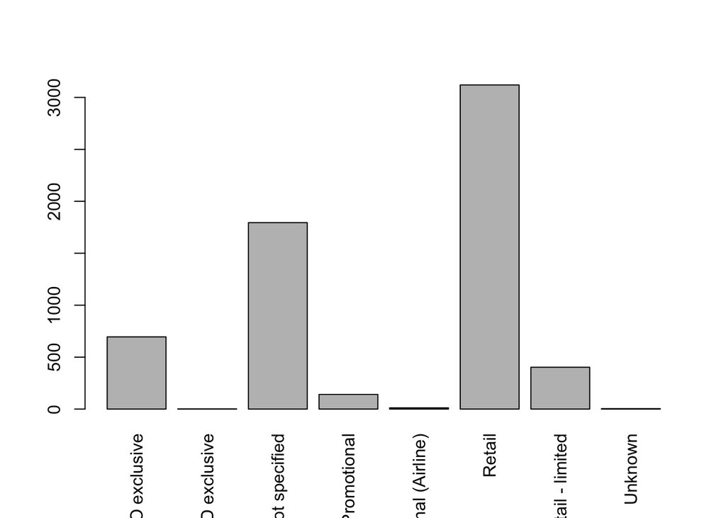

```r
barplot(table(legosets$Availability), las=3)
```

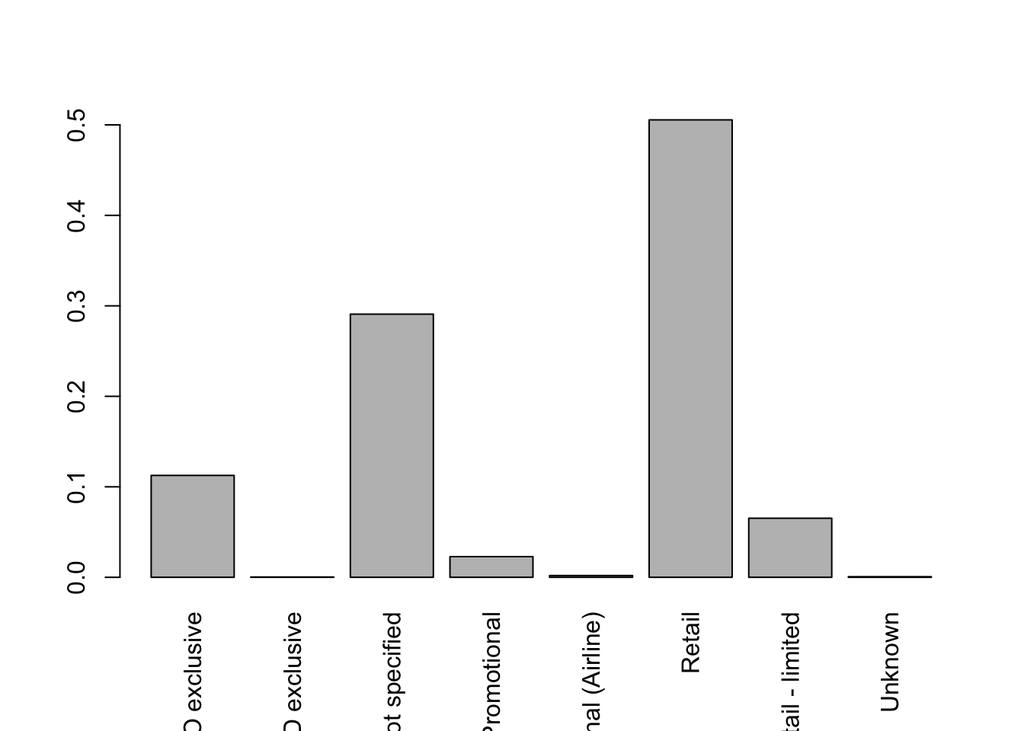

```r
barplot(prop.table(table(legosets$Availability)), las=3)
```

## Mosaic Plot

```r
library(vcd)
```

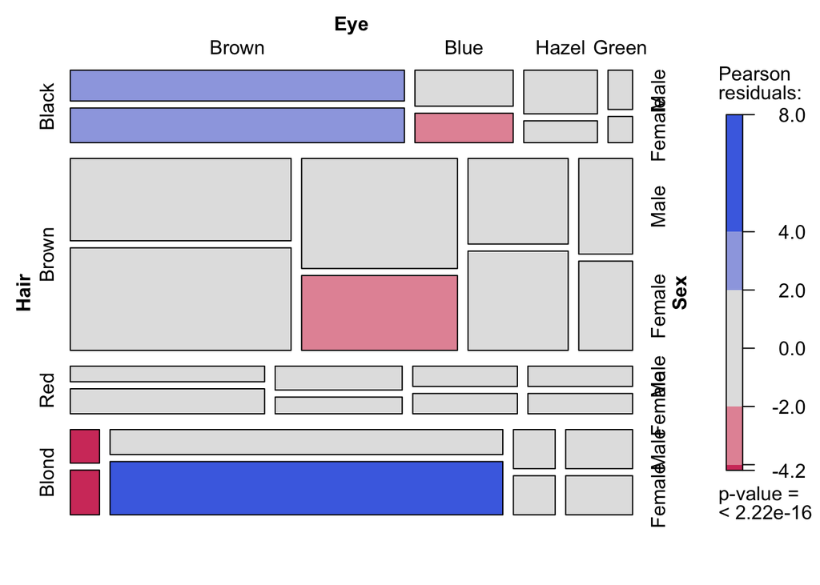

```r
mosaic(HairEyeColor, shade=TRUE, legend=TRUE)
```

## Measures of Center

```r
mean(legosets$Pieces, na.rm=TRUE)
```

```
## [1] 215.1686
```

```r
median(legosets$Pieces, na.rm=TRUE)
```

```
## [1] 82
```

## Measures of Spread

```r
var(legosets$Pieces, na.rm=TRUE)
```

```
## [1] 126876.8
```

```r
sqrt(var(legosets$Pieces, na.rm=TRUE))
```

```
## [1] 356.1976
```

```r
sd(legosets$Pieces, na.rm=TRUE)
```

```
## [1] 356.1976
```

```r
fivenum(legosets$Pieces, na.rm=TRUE)
```

```
## [1]    0.0   30.0   82.0  256.5 5922.0
```

```r
IQR(legosets$Pieces, na.rm=TRUE)
```

```
## [1] 226.25
```

## The summary Function

```r
summary(legosets$Pieces)
```

```
##    Min. 1st Qu.  Median    Mean 3rd Qu.    Max.    NA's
##     0.0    30.0    82.0   215.2   256.2  5922.0     112
```

## The psych Package

```r
library(psych)
describe(legosets$Pieces, skew=FALSE)
```

```
##    vars    n   mean    sd min  max range   se
## X1    1 6060 215.17 356.2   0 5922  5922 4.58
```

```r
describeBy(legosets$Pieces, group = legosets$Availability, skew=FALSE, mat=TRUE)
```

```
##     item                group1 vars    n      mean        sd min  max
## X11    1        LEGO exclusive    1  659 172.74203 442.96954   1 3428
## X12    2    LEGOLAND exclusive    1    2 211.00000 154.14928 102  320
## X13    3         Not specified    1 1747 145.87178 309.19929   1 5195
## X14    4           Promotional    1  140  53.97143 108.42721   1 1000
## X15    5 Promotional (Airline)    1   12 126.16667  47.01612  10  203
## X16    6                Retail    1 3094 245.78119 294.78052   0 3803
## X17    7      Retail - limited    1  402 410.94030 652.06435   1 5922
## X18    8               Unknown    1    4  27.50000  15.96872   6   44
##     range         se
## X11  3427  17.255643
## X12   218 109.000000
## X13  5194   7.397620
## X14   999   9.163772
## X15   193  13.572384
## X16  3803   5.299546
## X17  5921  32.522014
## X18    38   7.984360
```

## Dot Plot

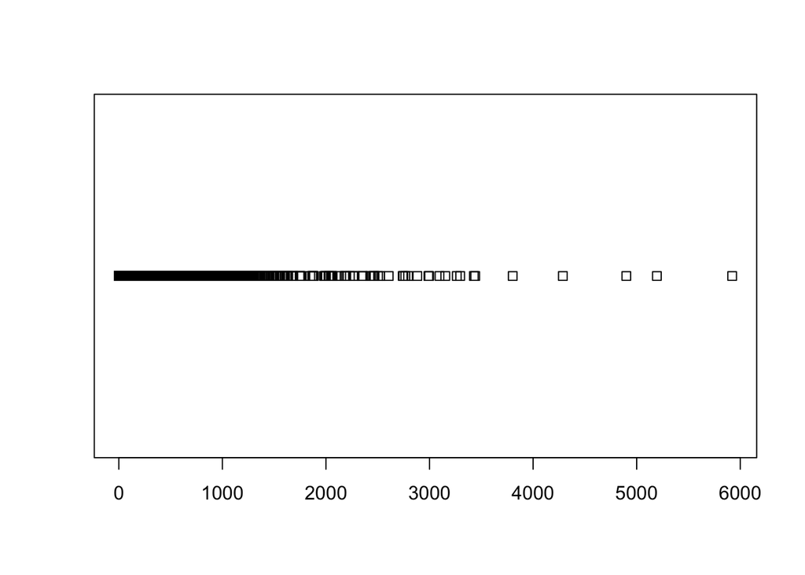

```r
stripchart(legosets$Pieces)
```

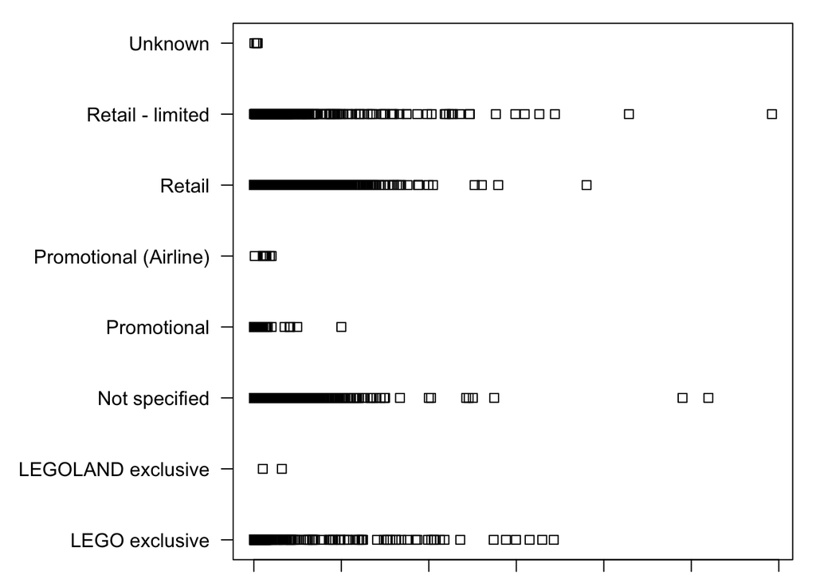

```r
par.orig <- par(mar=c(1,10,1,1))
stripchart(legosets$Pieces ~ legosets$Availability, las=1)
```

## Histograms

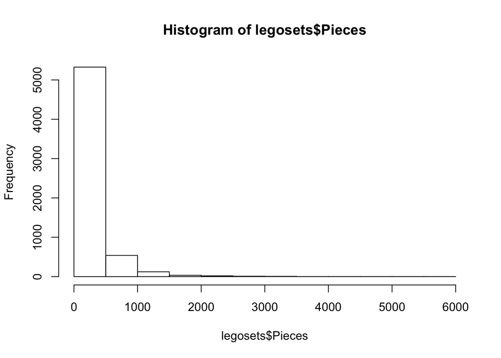

```r
hist(legosets$Pieces)
```

## Transformations

With highly skewed distributions, it is often helpful to transform the data. The log transformation is a common approach, especially when dealing with salary or similar data.

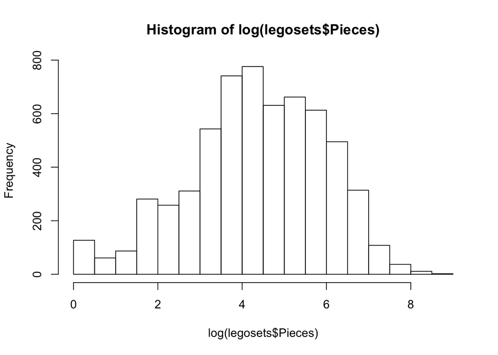

```r
hist(log(legosets$Pieces))
```

## Density Plots

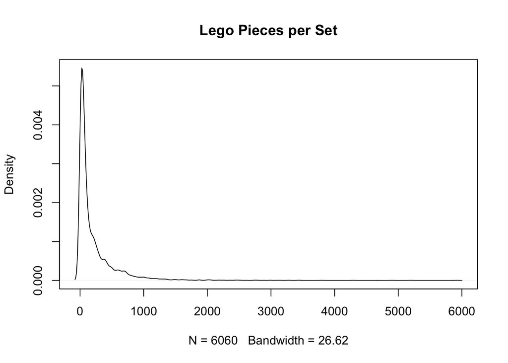

```r
plot(density(legosets$Pieces, na.rm=TRUE), main='Lego Pieces per Set')
```

## Box Plots

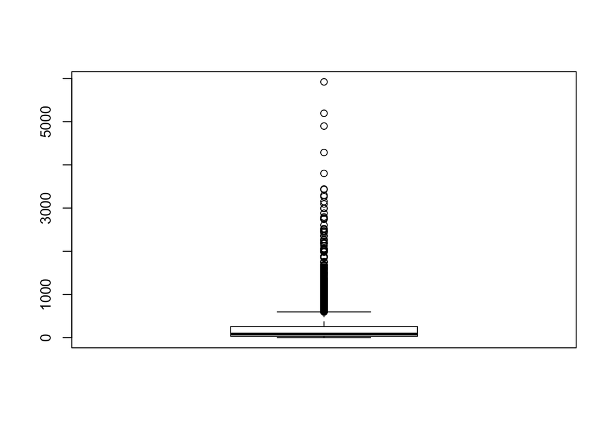

```r
boxplot(legosets$Pieces)
```

## Scatter Plots

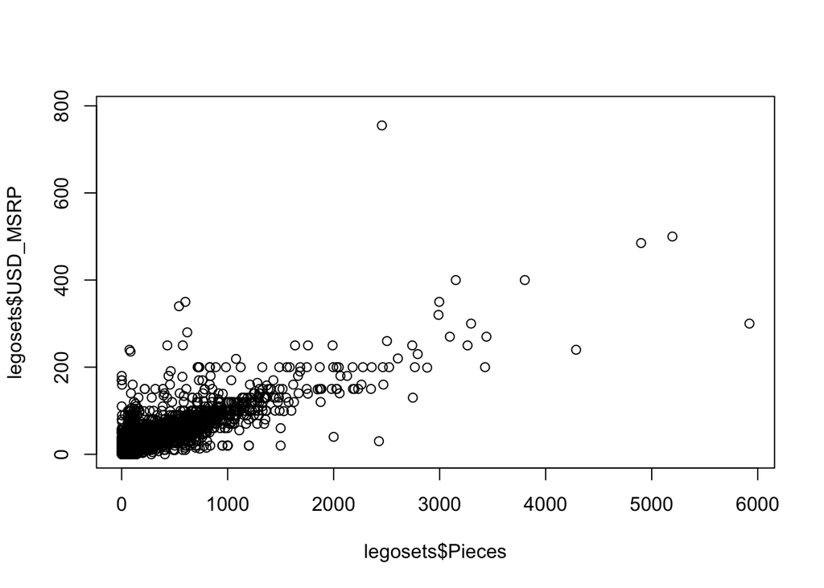

```r
plot(legosets$Pieces, legosets$USD_MSRP)
```

## Examining Possible Outliers

### expensive sets

```r
legosets[which(legosets$USD_MSRP >= 400),]
```

```
##      Item_Number                                   Name Year        Theme
## 901      2000430             Identity and Landscape Kit 2013 Serious Play
## 902      2000431                        Connections Kit 2013 Serious Play
## 2050     2000409                 Window Exploration Bag 2010 Serious Play
## 2852       10179 Ultimate Collector's Millennium Falcon 2007    Star Wars
##                       Subtheme Pieces Minifigures
## 901                                NA           6
## 902                              2455          NA
## 2050                             4900          NA
## 2852 Ultimate Collector Series   5195           5
##                                                 Image_URL GBP_MSRP
## 901  http://images.brickset.com/sets/images/2000430-1.jpg   509.99
## 902  http://images.brickset.com/sets/images/2000431-1.jpg   490.18
## 2050 http://images.brickset.com/sets/images/2000409-1.jpg   314.99
## 2852   http://images.brickset.com/sets/images/10179-1.jpg   342.49
##      USD_MSRP CAD_MSRP EUR_MSRP     Packaging  Availability
## 901    789.99   789.99   699.99 Not specified Not specified
## 902    754.99   754.99   559.99 Not specified Not specified
## 2050   484.99   484.99   359.99 Not specified Not specified
## 2852   499.99       NA       NA Not specified Not specified
```

### big sets

```r
legosets[which(legosets$Pieces >= 4000),]
```

```
##      Item_Number                                   Name Year
## 2047       10214                           Tower Bridge 2010
## 2050     2000409                 Window Exploration Bag 2010
## 2628       10189                              Taj Mahal 2008
## 2852       10179 Ultimate Collector's Millennium Falcon 2007
##                Theme                  Subtheme Pieces Minifigures
## 2047 Advanced Models                 Buildings   4287          NA
## 2050    Serious Play                             4900          NA
## 2628 Advanced Models                 Buildings   5922          NA
## 2852       Star Wars Ultimate Collector Series   5195           5
##                                                 Image_URL GBP_MSRP
## 2047   http://images.brickset.com/sets/images/10214-1.jpg   209.99
## 2050 http://images.brickset.com/sets/images/2000409-1.jpg   314.99
## 2628   http://images.brickset.com/sets/images/10189-1.jpg   199.99
## 2852   http://images.brickset.com/sets/images/10179-1.jpg   342.49
##      USD_MSRP CAD_MSRP EUR_MSRP     Packaging     Availability
## 2047   239.99   299.99   219.99           Box Retail - limited
## 2050   484.99   484.99   359.99 Not specified    Not specified
## 2628   299.99   399.99       NA           Box Retail - limited
## 2852   499.99       NA       NA Not specified    Not specified
```

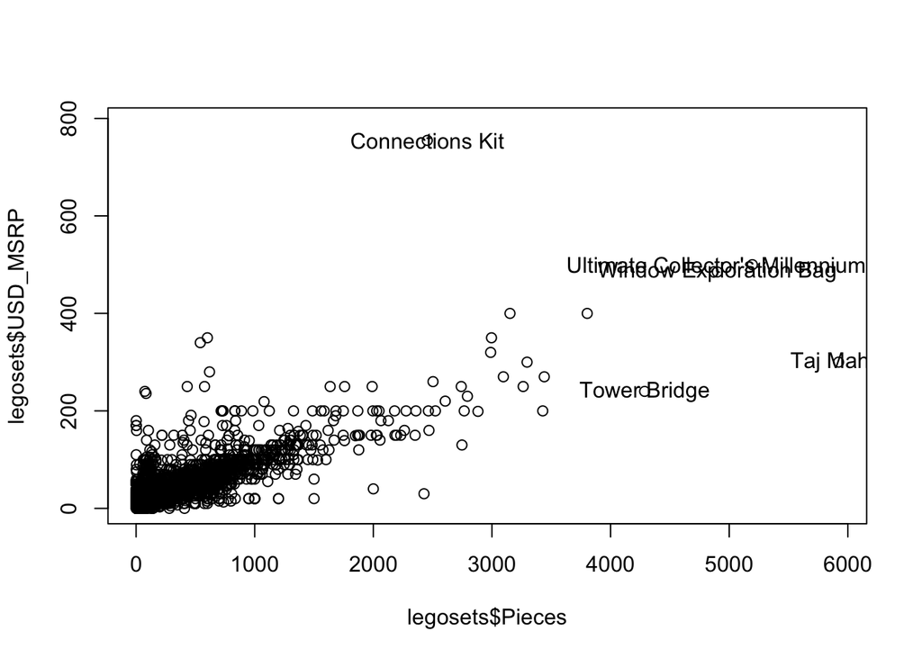

```r
plot(legosets$Pieces, legosets$USD_MSRP)
bigAndExpensive <- legosets[which(legosets$Pieces >= 4000 | legosets$USD_MSRP >= 400),]
text(bigAndExpensive$Pieces, bigAndExpensive$USD_MSRP, labels=bigAndExpensive$Name)
```

## Robust Statistics

Median and IQR are more robust to skewness and outliers than mean and SD. Therefore,

- for skewed distributions it is often more helpful to use median and IQR to describe the center and spread
- for symmetric distributions it is often more helpful to use the mean and SD to describe the center and spread

## Just say NO to pie charts!

“There is no data that can be displayed in a pie chart that cannot better be displayed in some other type of chart” –John Tukey